# Covid-19 by the Numbers

Josh Lewis

04/27/2023

# Covid-19

The Covid-19 pandemic was a devastating and unique event in our history. It created lasting transformations for society and still remains a controversial topic. Opinions range on masks, effectiveness of lock-down mandates, the lethality of the virus, and every facet of the pandemic.  
This presentation will examine the data set of number of deaths of individuals infected with Covid-19 at the time of their death. This data set was produced by the U.S Department of Health & Human Services and is available at this [link](https://catalog.data.gov/dataset/conditions-contributing-to-deaths-involving-coronavirus-disease-2019-covid-19-by-age-group). The data for 2020 and 2021 is final while 2022 and 2023 are provisional.  
The presentation will contain another data set to supplement the Covid-19 data set with national and state wide population figures. The presentation will use the 2020 census from the United States Census Bureau for population figures, available at this [link](https://data.census.gov/table?q=populatoin+totals+by+state&tid=DECENNIALPL2020.P1).

#### Questions

- Which condition contributed to more deaths
- How age is related to deaths
- Which year had the most deaths
- Death-rate per month
- Total deaths per State
- Percentage of deaths per State

# Libraries needed

```r
library(tidyr)
library(dplyr)
library(ggplot2)
library(usmap)
library(stringr)
library(knitr)
library(forcats)
```

### The data

```
##   Data.As.Of Start.Date   End.Date    Group Year Month         State
## 1 03/19/2023 01/01/2020 03/18/2023 By Total   NA    NA United States
## 2 03/19/2023 01/01/2020 03/18/2023 By Total   NA    NA United States
## 3 03/19/2023 01/01/2020 03/18/2023 By Total   NA    NA United States
## 4 03/19/2023 01/01/2020 03/18/2023 By Total   NA    NA United States
## 5 03/19/2023 01/01/2020 03/18/2023 By Total   NA    NA United States
## 6 03/19/2023 01/01/2020 03/18/2023 By Total   NA    NA United States
## 7 03/19/2023 01/01/2020 03/18/2023 By Total   NA    NA United States
## 8 03/19/2023 01/01/2020 03/18/2023 By Total   NA    NA United States
##        Condition.Group               Condition ICD10_codes Age.Group
## 1 Respiratory diseases Influenza and pneumonia     J09-J18      0-24
## 2 Respiratory diseases Influenza and pneumonia     J09-J18     25-34
## 3 Respiratory diseases Influenza and pneumonia     J09-J18     35-44
## 4 Respiratory diseases Influenza and pneumonia     J09-J18     45-54
## 5 Respiratory diseases Influenza and pneumonia     J09-J18     55-64
## 6 Respiratory diseases Influenza and pneumonia     J09-J18     65-74
## 7 Respiratory diseases Influenza and pneumonia     J09-J18     75-84
## 8 Respiratory diseases Influenza and pneumonia     J09-J18       85+
##   COVID.19.Deaths Number.of.Mentions Flag
## 1            1522               1594
## 2            5737               5954
## 3           14962              15580
## 4           37167              38622
## 5           81922              84922
## 6          127364             131353
## 7          135789             139045
## 8          118002             119809
```

### National total of deaths per pre-existing medical condition

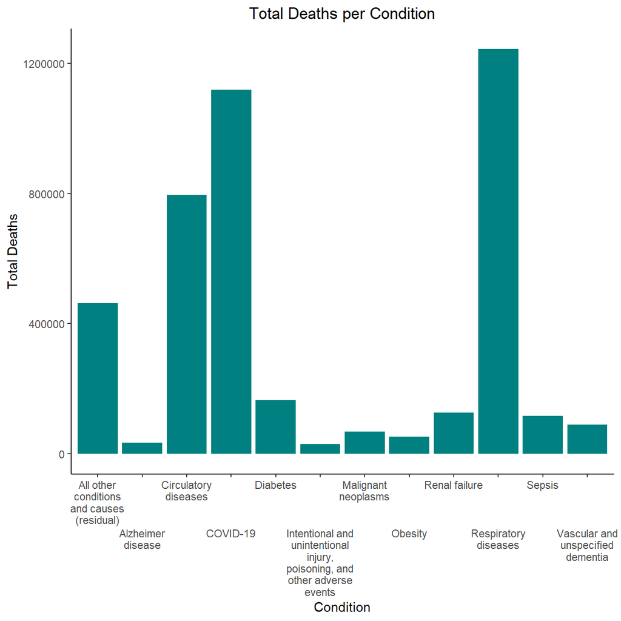

#### Total Deaths by Condition and Age.

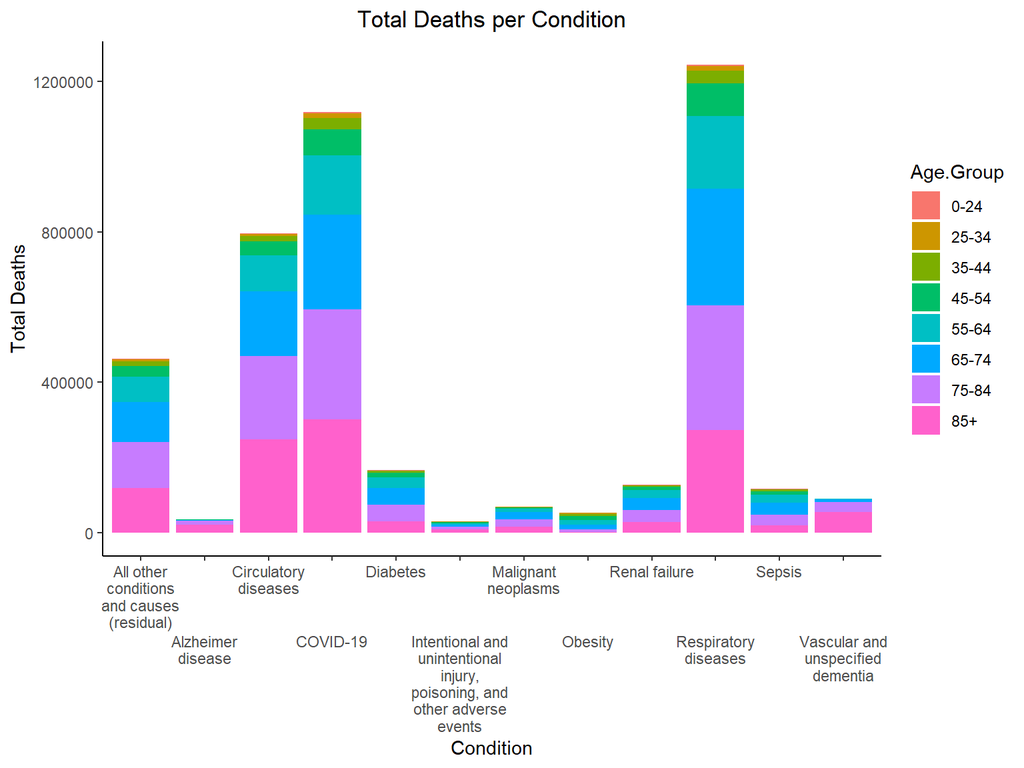

### National Total by Age.

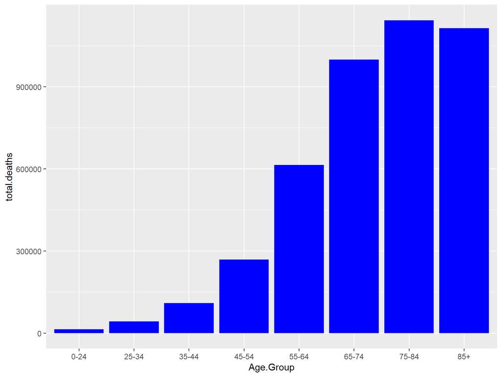

### Fill by Condition Group.

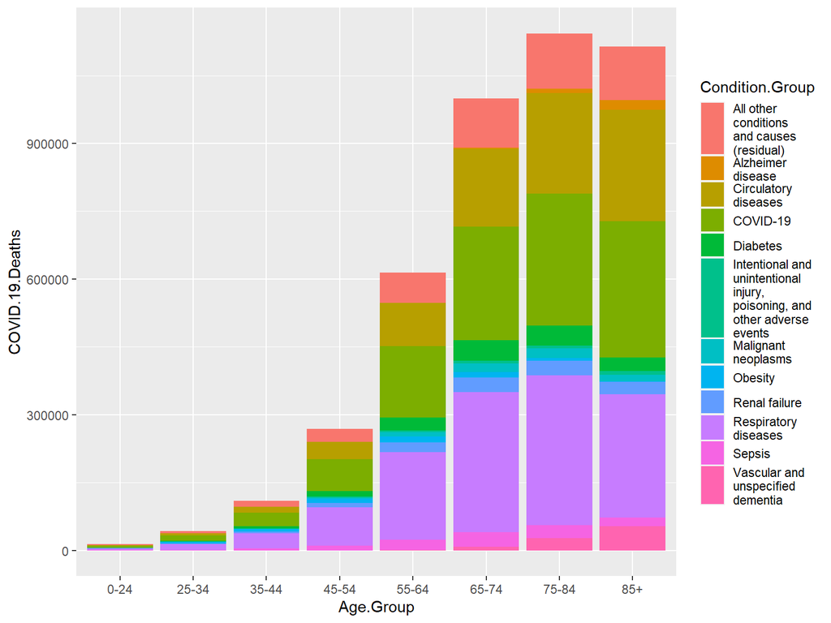

### Monthly Totals and timeline Covid-19 deaths.

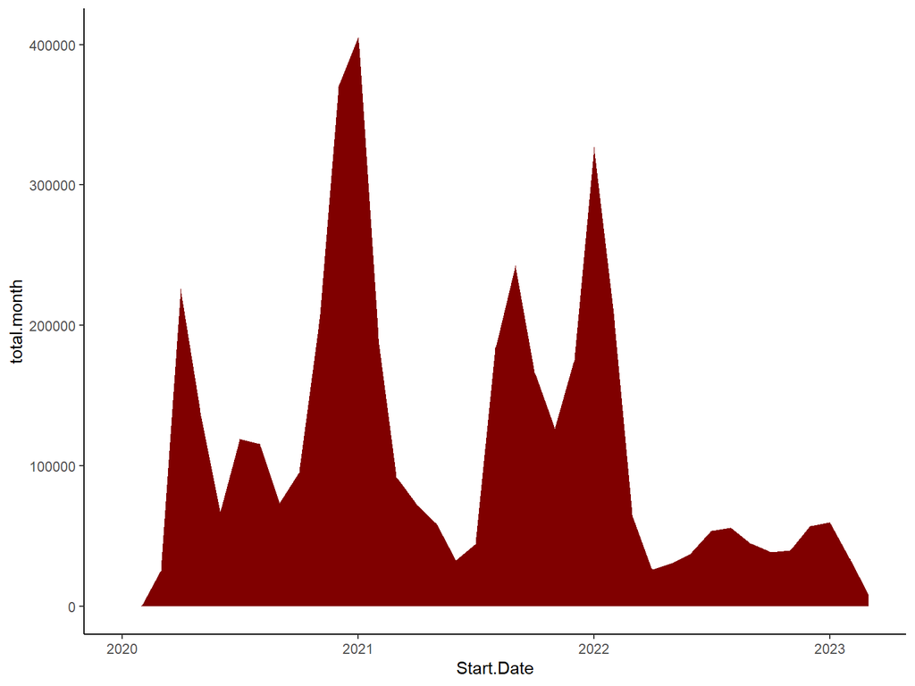

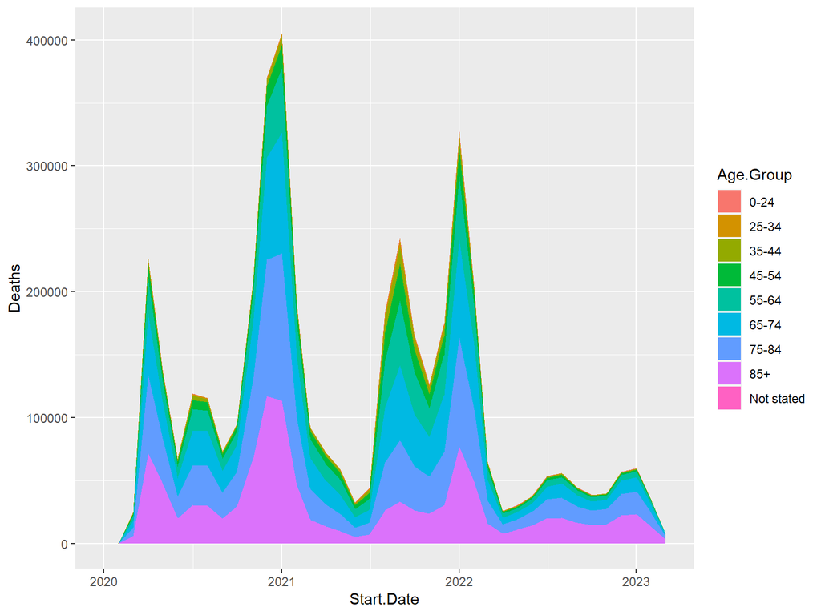

### Yearly Stats

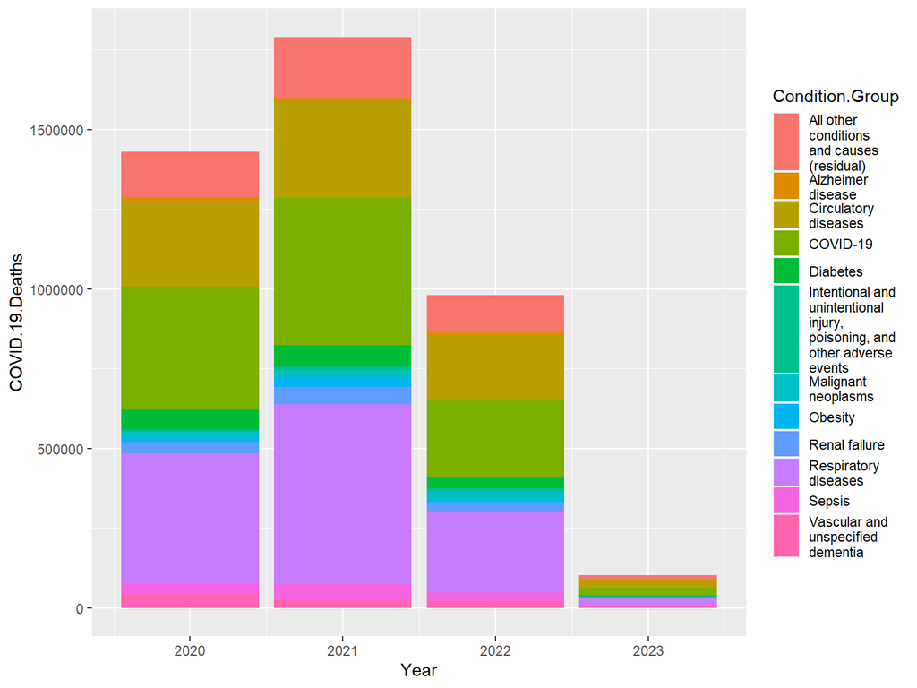

### Timeline of total deaths.

```r
create_total_to_date <- function(data_V) {
  new_V <- vector("integer", length(data_V))
  new_V[1] = data_V[1]
  for(x in 2:length(data_V))
    new_V[x] = new_V[x - 1] + data_V[x]
  return(new_V)
}
```

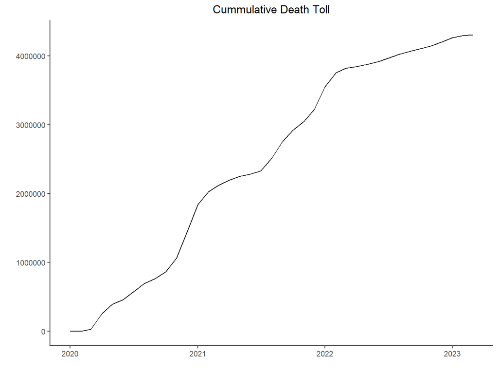

| State | Total Deaths |
| --- | --- |
| Alabama | 72468 |
| Alaska | 5216 |
| Arizona | 112213 |
| Arkansas | 47273 |
| California | 449590 |
| Colorado | 65110 |
| Connecticut | 42501 |
| Delaware | 12729 |
| Florida | 310537 |
| Georgia | 131782 |
| Hawaii | 6742 |
| Idaho | 22470 |
| Illinois | 142023 |
| Indiana | 104835 |
| Iowa | 40648 |
| Kansas | 36901 |
| Kentucky | 84495 |
| Louisiana | 63912 |
| Maine | 9111 |
| Maryland | 70738 |
| Massachusetts | 75850 |
| Michigan | 126439 |
| Minnesota | 63951 |
| Mississippi | 61315 |
| Missouri | 79804 |
| Montana | 16567 |
| Nebraska | 23419 |
| Nevada | 50710 |
| New Hampshire | 10968 |
| New Jersey | 135976 |
| New Mexico | 30116 |
| New York | 269539 |
| North Carolina | 125091 |
| North Dakota | 12080 |
| Ohio | 179070 |
| Oklahoma | 73207 |
| Oregon | 35839 |
| Pennsylvania | 195709 |
| Rhode Island | 15308 |
| South Carolina | 80486 |
| South Dakota | 14915 |
| Tennessee | 111040 |
| Texas | 403124 |
| Utah | 22549 |
| Vermont | 3814 |
| Virginia | 76671 |
| Washington | 64273 |
| West Virginia | 30299 |
| Wisconsin | 67370 |
| Wyoming | 7151 |

| U.S. Total Deaths |
| --- |
| 4303825 |

### The states

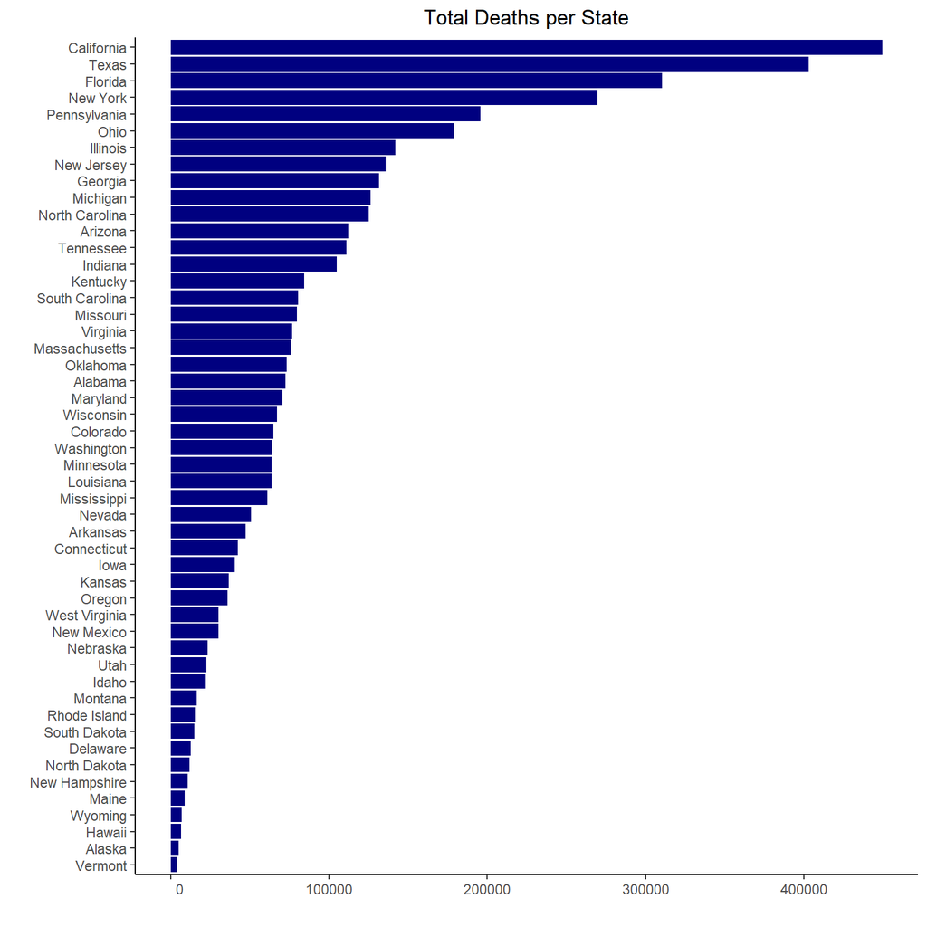

#### Top 9 States

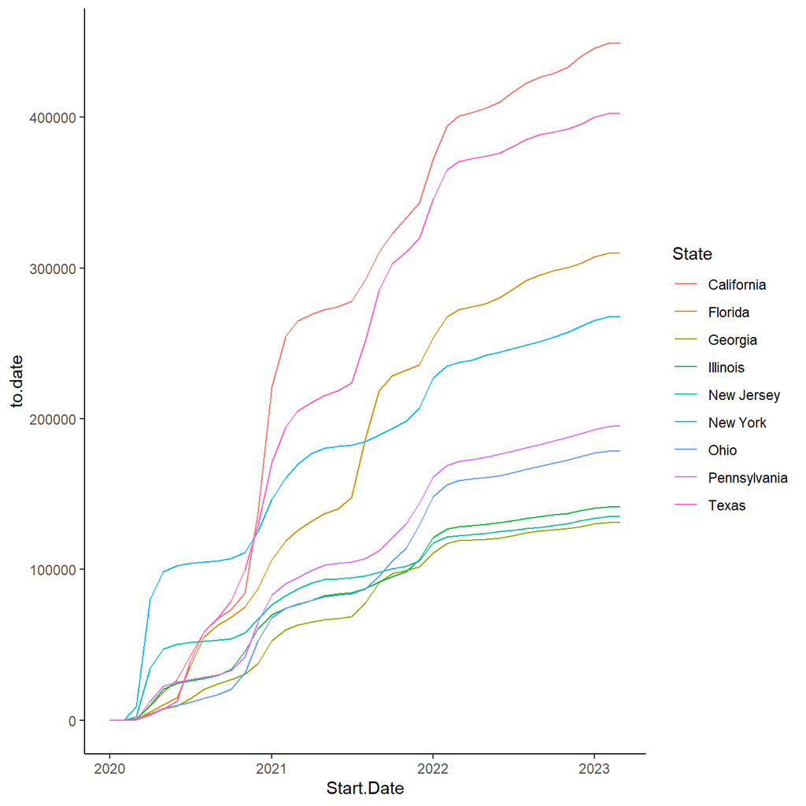

|  | percentage |
| --- | --- |
| Alabama | 1.442 |
| Alaska | 0.711 |
| Arizona | 1.569 |
| Arkansas | 1.570 |
| California | 1.137 |
| Colorado | 1.128 |
| Connecticut | 1.179 |
| Delaware | 1.286 |
| Florida | 1.442 |
| Georgia | 1.230 |
| Hawaii | 0.463 |
| Idaho | 1.222 |
| Illinois | 1.108 |
| Indiana | 1.545 |
| Iowa | 1.274 |
| Kansas | 1.256 |
| Kentucky | 1.875 |
| Louisiana | 1.372 |
| Maine | 0.669 |
| Maryland | 1.145 |
| Massachusetts | 1.079 |
| Michigan | 1.255 |
| Minnesota | 1.121 |
| Mississippi | 2.071 |
| Missouri | 1.297 |
| Montana | 1.528 |
| Nebraska | 1.194 |
| Nevada | 1.633 |
| New Hampshire | 0.796 |
| New Jersey | 1.464 |
| New Mexico | 1.422 |
| New York | 1.334 |
| North Carolina | 1.198 |
| North Dakota | 1.551 |
| Ohio | 1.518 |
| Oklahoma | 1.849 |
| Oregon | 0.846 |
| Pennsylvania | 1.505 |
| Rhode Island | 1.395 |
| South Carolina | 1.572 |
| South Dakota | 1.682 |
| Tennessee | 1.607 |
| Texas | 1.383 |
| Utah | 0.689 |
| Vermont | 0.593 |
| Virginia | 0.888 |
| Washington | 0.834 |
| West Virginia | 1.689 |
| Wisconsin | 1.143 |
| Wyoming | 1.240 |

### State Percentages

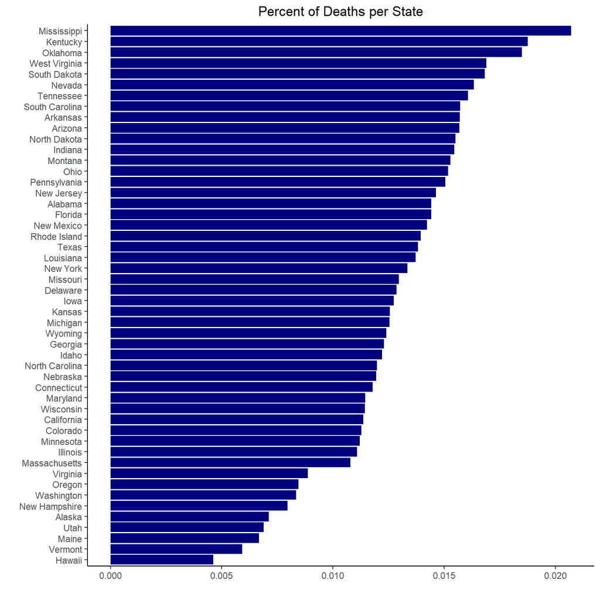

#### US Map

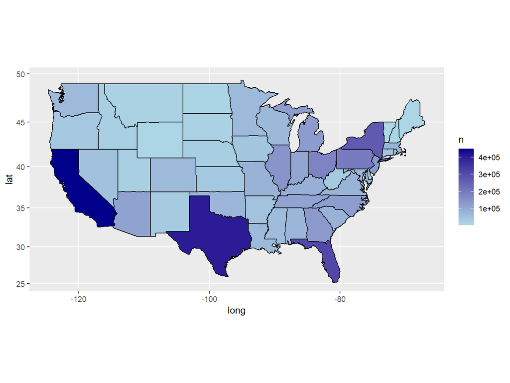

### US Map with Percentage

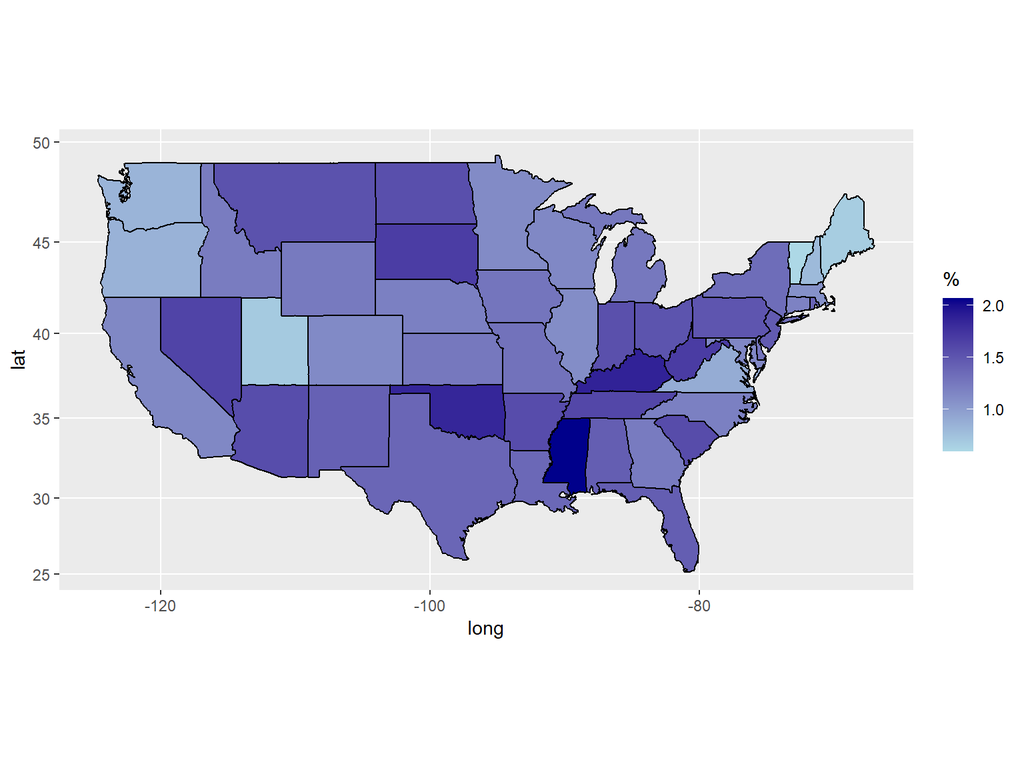